# Homework 03

Alabboodi, Ammar (email: ANA154@pitt.edu)

today

# Overview

##### This analysis explores TikTok posts that use the hashtag **#edrecovery**, which stands for *eating disorder recovery*. The goal is to understand common themes and communities emerging around this tag by examining co-occurring hashtags, performing text-based clustering, and visualizing groupings using dimensionality reduction.

##### We obtained the data from a CSV file named `tiktok_hashtags.csv`, which contains usernames and associated hashtags used in TikTok posts. Each row represents a post and its corresponding hashtag string.

The main steps in this analysis include:

- **Parsing and normalizing hashtags**, extracting all hashtags from each post and standardizing them (lowercasing and cleaning).
- **Identifying top co-occurring hashtags** with `#edrecovery` to highlight commonly discussed topics.
- **Constructing a Document-Term Matrix (DTM)** and applying **TF–IDF (Term Frequency - Inverse Document Frequency) weighting** to emphasize significant hashtags per post.
- **Clustering posts** using **K-means** based on their hashtag profiles to uncover distinct communities or thematic groups.
- **Visualizing clusters** using **Principal Component Analysis (PCA)** to reduce dimensionality and reveal separable clusters.
- **Profiling each cluster** by identifying the most representative hashtags for interpretation.

##### This process helps us explore how TikTok users engage with the concept of recovery, the narratives they construct, and the subcultures that form within the broader #edrecovery discourse.

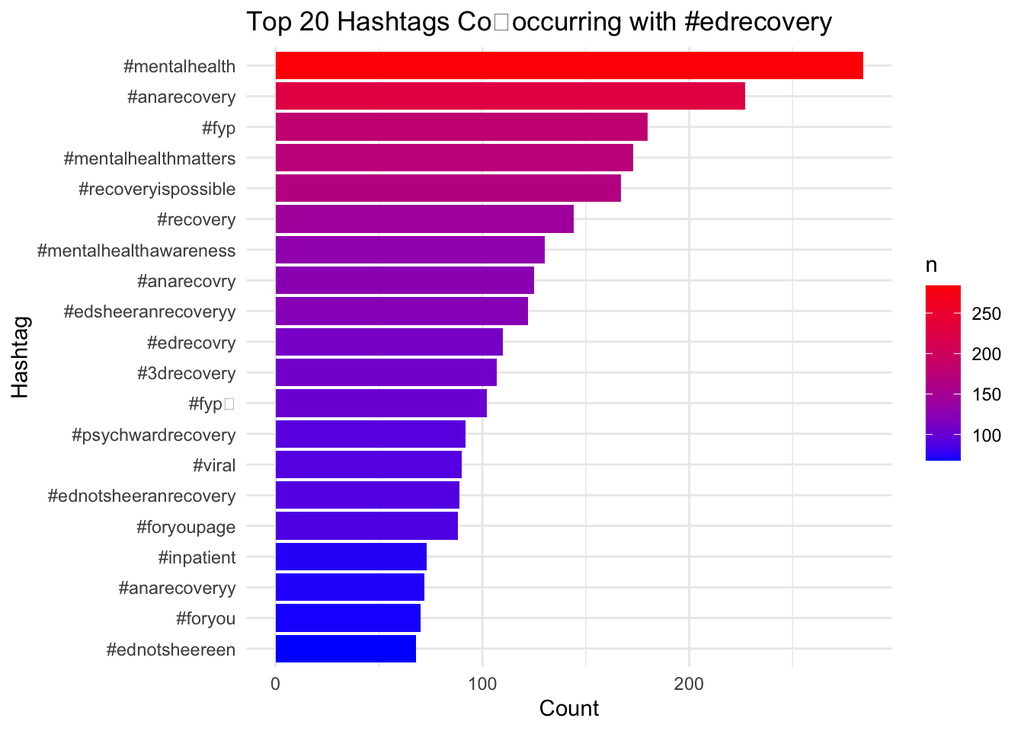

```r
# install.packages(c("tidyverse","tidytext","tm","ggplot2","factoextra"))
library(tidyverse)
library(tidytext)
library(tm)
library(ggplot2)
library(factoextra)
# Load & parse
df <- read_csv("tiktok_hashtags.csv")
df <- df %>%
  mutate(
    # extract all "#word" tokens
    tags = str_extract_all(hashtags, "#\\w+"),
    # normalize: lowercase + replace zero→o + unique
    tags = map(tags, ~ unique(tolower(gsub("0", "o", .x)))),
    # add a doc_id for later joins
    doc_id = row_number()
  )

# Co‑occurrence with #edrecovery
ed_df <- df %>%
  filter(map_lgl(tags, ~ "#edrecovery" %in% .x))

co_occur <- ed_df %>%
  unnest(tags) %>%
  filter(tags != "#edrecovery") %>%
  count(tags, sort = TRUE) %>%
  slice_head(n = 20)

ggplot(co_occur, aes(x = reorder(tags, n), y = n, fill = n)) +
  geom_col() +
  coord_flip() +
  scale_fill_gradient(low = "blue", high = "red") +
  labs(
    title = "Top 20 Hashtags Co‑occurring with #edrecovery",
    x = "Hashtag", y = "Count"
  ) +
  theme_minimal()
```

## Co‑occurrence Analysis

To better understand the thematic context of posts using **#edrecovery**, we first identified all hashtags that co-occur with it. After loading and parsing the dataset, we extracted hashtags from each post, normalized them by lowercasing and replacing zeros with the letter “o”, and assigned a unique document ID to each entry.

We then filtered the dataset to include only those posts containing `#edrecovery` and computed the frequency of all other hashtags that appear alongside it. The top 20 co-occurring hashtags were visualized using a horizontal bar chart with a gradient fill, emphasizing which tags most frequently accompany `#edrecovery`.

This analysis gives us an initial glimpse into the most common themes and conversations that surround the recovery community on TikTok.

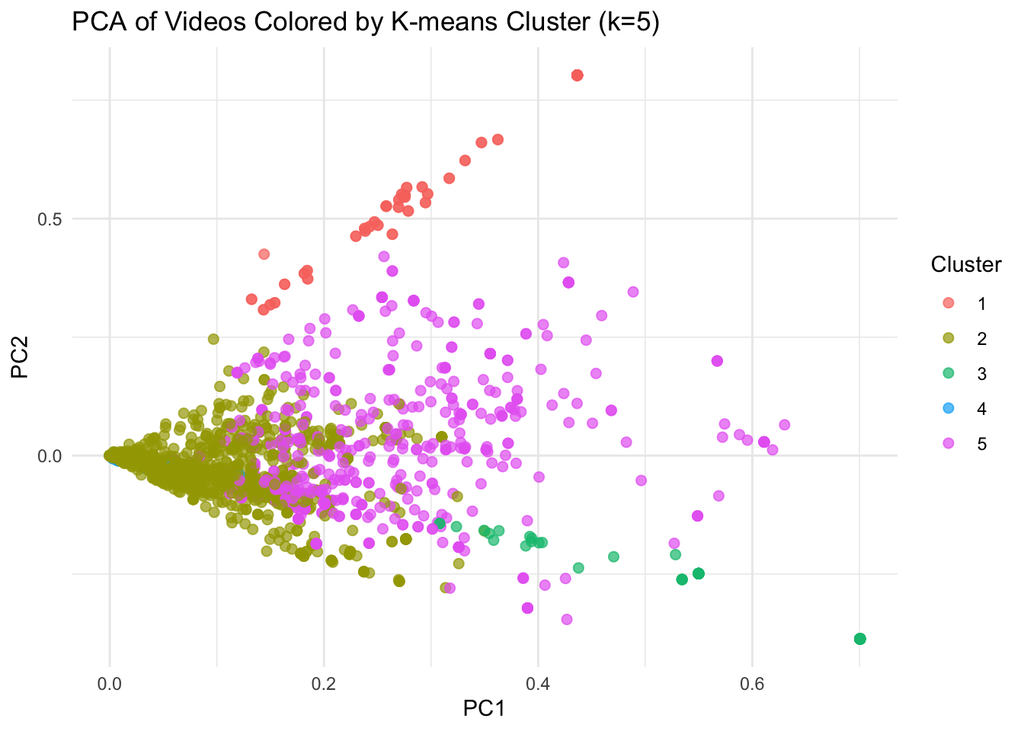

```r
# Build a DTM with TF-IDF for all videos
docs <- df %>%
  transmute(
    doc_id,
    text = map_chr(tags, paste, collapse = " ")
  )

# Remove any rows with N/A or missing terms
docs <- docs %>% filter(!is.na(text) & text != "")

# Create the DTM
dtm <- docs %>%
  unnest_tokens(term, text) %>%
  count(doc_id, term, sort = FALSE) %>%
  cast_dtm(doc_id, term, n)

# Apply TF-IDF weighting
dtm_tfidf <- weightTfIdf(dtm)
m <- as.matrix(dtm_tfidf)

# Remove empty documents (rows with no terms)
non_empty <- rowSums(m) > 0
m_nz <- m[non_empty, ]

# L2-normalize each row (document)
row_norms <- sqrt(rowSums(m_nz^2))
m_nz <- m_nz / row_norms

# Choose k (number of clusters) ≤ nrow(m_nz)−1
k <- min(5, nrow(m_nz) - 1)
set.seed(42)
km <- kmeans(m_nz, centers = k, nstart = 25)

# Perform PCA on the normalized matrix
pca_res <- prcomp(m_nz, center = FALSE, scale. = FALSE)
scores <- data.frame(
  PC1 = pca_res$x[,1],
  PC2 = pca_res$x[,2],
  cluster = factor(km$cluster)
)

# Plot the results
library(ggplot2)
ggplot(scores, aes(x = PC1, y = PC2, color = cluster)) +
  geom_point(alpha = 0.7, size = 2) +
  labs(
    title = paste0("PCA of Videos Colored by K-means Cluster (k=", k, ")"),
    x = "PC1", y = "PC2", color = "Cluster"
  ) +
  theme_minimal()
```

## Clustering and Dimensionality Reduction

To identify latent themes among all TikTok posts—not just those containing `#edrecovery`—we constructed a **Document-Term Matrix (DTM)** using the full set of normalized hashtags. We applied **TF–IDF weighting** to emphasize hashtags that are more informative within individual posts while down-weighting those that are too common across the dataset.

After removing empty documents, we performed **L2 normalization** on the TF–IDF matrix to prepare it for clustering. We used **K-means clustering** (with `k` set dynamically to a maximum of 5, or fewer if the dataset was smaller) to group posts based on hashtag similarity.

### Graph Reading

That scatter is a map of videos in a two‑dimensional “hashtag space,” where:

**PC1 (x‑axis)** captures the single biggest direction of variation in how videos use hashtags.

**PC2 (y‑axis)** captures the next‑biggest, orthogonal direction of variation.

**Clusters (colors):** Videos in the same color are those that the k‑means algorithm judged to have similar TF–IDF hashtag signatures.

**Distance from each other:** Two videos plotted close together used almost the same mix of hashtags.

**Distance from the origin:** Videos far out on PC1 or PC2 have “extreme” hashtag mixes in that direction. Videos near (0,0) use a more “average” combination. **Cluster separation:** Well‑separated blobs mean distinct hashtag communities. Overlap suggests videos that mix hashtags from multiple themes.

```r
loadings <- as.data.frame(pca_res$rotation[,1:2])
# show top positive/negative hashtags on PC1
head(arrange(loadings, desc(PC1)), 10)
```

```
##                           PC1          PC2
## edrecovery          0.3259355 -0.193220413
## recoveryispossible  0.2838019  0.326971167
## fyp                 0.2765249 -0.176166859
## recoverytok         0.2560255  0.420154709
## 3drecovery          0.2475108  0.203485741
## mentalhealthmatters 0.2222289 -0.005893994
## mentalhealth        0.2220142 -0.104768987
## anarecovry          0.2107249 -0.115194729
## anarecovery         0.2047522 -0.039310268
## シ                  0.1943413 -0.150222006
```

```r
head(arrange(loadings, PC1), 10)
```

```
##                 PC1 PC2
## hispanic          0   0
## latina            0   0
## nosabokid         0   0
## ilovebooks        0   0
## literaryfiction   0   0
## oceanvuong        0   0
## reader            0   0
## richardsiken      0   0
## sallyrooney       0   0
## veschwab          0   0
```

```r
library(dplyr)
library(tidyr)
# 1. Ensure no NAs in the 'tags' column of df
df_clean <- df %>%
  filter(!is.na(tags) & tags != "")  # Remove rows with NAs or empty tags

# Build a DTM with TF-IDF for all videos
docs <- df_clean %>%
  transmute(
    doc_id,
    text = map_chr(tags, paste, collapse = " ")
  )

# Create the DTM
dtm <- docs %>%
  unnest_tokens(term, text) %>%
  count(doc_id, term, sort = FALSE) %>%
  cast_dtm(doc_id, term, n)

# Apply TF-IDF
dtm_tfidf <- weightTfIdf(dtm)
m <- as.matrix(dtm_tfidf)

# 2. Remove any all-zero rows (this ensures no empty documents)
non_zero_mask <- rowSums(m) > 0
m_nz <- m[non_zero_mask, , drop = FALSE]
valid_doc_ids <- as.integer(rownames(m_nz))

# 3. Run k-means on the filtered matrix
k <- min(5, nrow(m_nz) - 1)
set.seed(42)
km <- kmeans(m_nz, centers = k, nstart = 25)

# 4. Build a map of doc_id → cluster
cluster_map <- tibble(
  doc_id = valid_doc_ids,
  cluster = factor(km$cluster)
)

# 5. Subset the original df by valid doc_ids (those that are not empty or NA)
df_nz <- df_clean %>%
  filter(doc_id %in% valid_doc_ids) %>%
  left_join(cluster_map, by = "doc_id")

# 6. Now unnest and tally top tags per cluster
top_tags_per_cluster <- df_nz %>%
  unnest(tags) %>%
  group_by(cluster, tags) %>%
  summarise(count = n(), .groups = "drop") %>%
  arrange(cluster, desc(count)) %>%
  group_by(cluster) %>%
  slice_head(n = 5)

print(top_tags_per_cluster)
```

```
## # A tibble: 18 × 3
## # Groups:   cluster [5]
##    cluster tags                       count
##    <fct>   <chr>                      <int>
##  1 1       #greenscreenvideo              4
##  2 1       #onthisday                     3
##  3 1       #collegelife                   2
##  4 2       #recovery                     94
##  5 2       #edrecovery                   91
##  6 2       #edrecovry                    79
##  7 2       #anarecoveryy                 70
##  8 2       #anarecovery                  59
##  9 3       #real                         28
## 10 3       #exerciseaddictionrecovery     8
## 11 4       #ootd                         10
## 12 4       #fitcheck                      2
## 13 4       #gifted                        1
## 14 5       #fyp                         831
## 15 5       #edrecovery                  542
## 16 5       #mentalhealth                444
## 17 5       #recoveryispossible          438
## 18 5       #mentalhealthmatters         395
```

# Cluster Interpretation of #edrecovery TikTok Hashtag Data

## Cluster 1: #personal_reflection — Nostalgia and Identity Exploration

**Top hashtags:** #greenscreenvideo (4), #onthisday (3), #collegelife (2)

**Description:**

This cluster reflects content centered around personal reflection, nostalgic moments, and identity exploration. Hashtags like #greenscreenvideo indicate the use of multimedia tools, possibly adding a creative layer to personal storytelling. The presence of #onthisday points to a focus on remembering significant past events, and #collegelife suggests a connection to youthful or academic experiences, indicating that users in this cluster may be revisiting or reflecting on their journey, particularly during the college years.

### Cluster 2: #mental_health_struggles — Mental Health & Recovery Challenges

**Top hashtags:** #recovery (94), #edrecovery (91), #edrecovry (79), #anarecoveryy (70), #anarecovery (59)

**Description:**

This cluster captures themes of mental health recovery, with a particular focus on eating disorders. The hashtags #edrecovery, #edrecovry, #anarecoveryy, and #anarecovery emphasize struggles and recovery from eating disorders, while #recovery and #edrecovery are commonly used in broader mental health discussions. The recurrence of similar recovery-focused hashtags suggests that this cluster is dedicated to sharing personal recovery narratives, supporting those on similar journeys, and fostering a sense of community and solidarity.

### Cluster 3: #authenticity_and_vulnerability — Raw and Unfiltered Recovery Stories

**Top hashtags:** #real (28), #exerciseaddictionrecovery (8)

**Description:**

This cluster emphasizes authenticity and vulnerability in the context of mental health and recovery. The dominant hashtag, #real, reflects content that likely focuses on raw, unfiltered personal experiences. It’s a space for those who reject the polished or curated side of social media, sharing what recovery really looks like. The addition of #exerciseaddictionrecovery points to a specific form of recovery, indicating that users in this cluster may also be grappling with addiction and the journey to overcome it.

### Cluster 4: #style_and_self_image — Appearance and Personal Expression

**Top hashtags:** #ootd (10), #fitcheck (2), #gifted (1)

**Description:**

This cluster blends elements of personal expression and self-image with the theme of recovery. The hashtag #ootd (outfit of the day) is a common marker for showcasing personal style, while #fitcheck suggests a focus on physical appearance, likely tying into body image and self-confidence issues. The inclusion of #gifted may indicate a connection to personal growth or empowerment, possibly in the context of recognizing strengths during recovery or self-reflection.

### Cluster 5: #mainstream_recovery_and_awareness — Broad Mental Health Advocacy

**Top hashtags:** #fyp (831), #edrecovery (542), #mentalhealth (444), #recoveryispossible (438), #mentalhealthmatters (395)

**Description:**

The largest cluster, this one represents a broad and mainstream approach to recovery and mental health advocacy. The prominence of the #fyp hashtag indicates that this content is aimed at reaching a wide audience on TikTok, likely showing up on users’ For You Pages. Hashtags like #mentalhealth, #recoveryispossible, and #mentalhealthmatters suggest a focus on awareness, hope, and support, making this cluster central to the broader conversation around mental health recovery and solidarity. This cluster is likely filled with educational content, inspirational messages, and general recovery-related discussions aimed at a wide and diverse audience.

```r
# Compute Purity and Entropy per cluster
library(dplyr)

# Helper function for entropy
entropy <- function(p) {
  p <- p[p > 0]
  -sum(p * log2(p))
}

# Purity and entropy calculation
cluster_eval <- df_nz %>%
  unnest(tags) %>%
  group_by(cluster, tags) %>%
  summarise(count = n(), .groups = "drop") %>%
  group_by(cluster) %>%
  mutate(total = sum(count),
         prop = count / total) %>%
  summarise(
    top_tag = first(tags),
    top_tag_prop = max(prop),
    cluster_entropy = entropy(prop)
  )

cluster_eval
```

```
## # A tibble: 5 × 4
##   cluster top_tag                    top_tag_prop cluster_entropy
##   <fct>   <chr>                             <dbl>           <dbl>
## 1 1       #collegelife                     0.444            1.53
## 2 2       #1                               0.0906           5.56
## 3 3       #exerciseaddictionrecovery       0.778            0.764
## 4 4       #fitcheck                        0.769            0.991
## 5 5       #1                               0.0509           8.73
```